# Day 14–Using CLT

## The Central Limit Theorem

- there is a statistic from the population we want to know about (often average or proportion) **population parameter**
- we can take a sample of size $n$, and measure the statistic for the sample, **sample statistic**
- Goal: estimate the population parameter using a sample statistic. (the sample statistic is sometimes referred to as a **point estimate**)
- if we can repeatedly sample from our population at a fixed sample size, the sample statistics will be centered around the population parameter
- the central limit theorem says it will be normally distributed
- What normal distribution? What is the center? How spread out is it?

### Conditions for Using CLT for means

- **normality condition**:
  - if your sample size is large enough, then this is met automatically.
  - if your sample size $n \leq 30$, then your population needs to be approximately normally distributed.
  - rule of thumb: if $n \leq 30$ there needs to be no significant outliers
- **independence condition**:
  - sampling needs to be an independent process
  - we are fine if we use simple random sampling

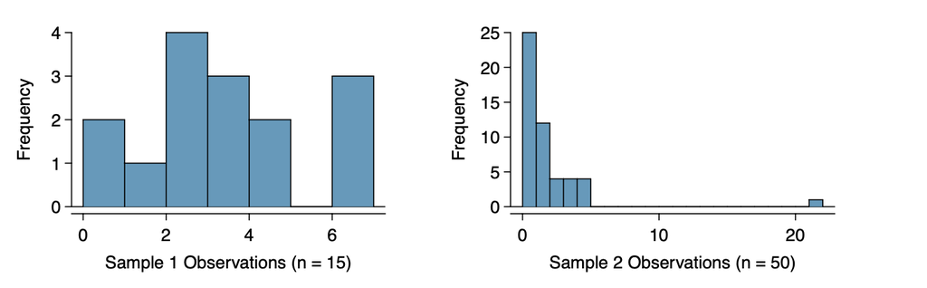

Image source: OpenIntro

## CLT for means

- $\mu$ is the population mean
- $\bar{X}$ is the sample mean
- $\sigma$ is the population standard deviation
- $s$ is the sample sample standard deviation
- $n$ is sample size
- the standard deviation of the sampling distribution is called the **standard error**

$$\bar{X} \sim N
\left(\mu,\frac{\sigma}{\sqrt{n}} \right)$$

- as sample size increases ($n$ gets large), the standard error gets small, and so, the sampling distribution is more narrow around the population mean.

Example: Suppose that the population mean is $5$ and the population standard deviation is $12$. What is the probability that a simple random sample of size $36$ will have a sample mean greater than $7$?

```r
z_score <- (7-5)/(12/sqrt(36))
1-pnorm(1)
```

```
## [1] 0.1586553
```

```r
pnorm(1,lower.tail = FALSE)
```

```
## [1] 0.1586553
```

```r
1-pnorm(7,5,12/sqrt(36))
```

```
## [1] 0.1586553
```

```r
# There is a 15.8% chance that if you take a sample of size 36 from a population with mean 5 and standard deviation 12, that the sample mean will be larger than 7.
```

Activity:

1. A population has mean $\mu = 143$ and standard deviation $\sigma = 15$. Describe the sampling distribution for a sample of size $150$. Draw a picture of the sampling distribution. Label the area corresponding to the probability of a sample mean greater than $144$. Find the probability.
2. A population has mean $\mu = 22$ and standard deviation $\sigma = 1.4$. What is the standard error if the sample size is $50$. How many standard errors away from the population mean is a sample mean of $\bar{X} = 23$? Find the probability that a sample mean of size $50$ has mean less than 23.
3. A population has mean $\mu = 22$ and standard deviation $\sigma = 1.4$. You plan to take a sample of $50$ observations. Find a the $2.5$ percentile and the $97.5$ percentile of the sampling distribution for the sample mean.
- to do this problem, you need the z-score corresponding to 97.5 and 2.5 percentile

```r
qnorm(.975)
```

```
## [1] 1.959964
```

```r
qnorm(.025)
```

```
## [1] -1.959964
```